# Atividade 5: solução dos exemplos do livro

Leonardo P. Migliorini

#### Tabela 7.7 - Estudo sobre doença coronária arterial

Abaixo temos a tabela com os dados coletados no estudo sobre doença coronária arterial. Temos 3 variáveis, Sexo, ECG e presença ou ausência de doença no paciente.

| Sexo | ECG | Presente | Ausente | Total |
| --- | --- | --- | --- | --- |
| Feminino | < 0,1 ST | 4 | 11 | 15 |
| Feminino | >= 0,1 ST | 8 | 10 | 18 |
| Masculino | < 0,1 ST | 9 | 9 | 18 |
| Masculino | >= 0,1 ST | 21 | 6 | 27 |

Ajustando os modelos encaixados, considerando a presença de doença como variável resposta e Sexo e ECG como covariáveis dos modelos. Uma tabela para a Análise de Deviance (ANODEV) é apresentada abaixo:

| Modelo | Resid. Df | Resid. Dev | Df | Deviance | Pr(>Chi) |
| --- | --- | --- | --- | --- | --- |
| Modelo 1: ~1 | 77 | 107.66897 | NA | NA | NA |
| Modelo 2: ~Sexo | 76 | 100.54807 | 1 | 7.1208932 | 0.0076191 |
| Modelo 3: ~Sexo + ECG | 75 | 95.89960 | 1 | 4.6484737 | 0.0310812 |
| Modelo 4: ~Sexo * ECG | 74 | 95.68551 | 1 | 0.2140933 | 0.6435778 |

Pode-se observar que o modelo 2 apresentou diferença significativa no deviance em relação ao modelo nulo, indicando que a variável Sexo é importante para explicar o desenvolvimento de doença coronária. Ainda o modelo 3 teve diferença significativa no deviance em relação ao modelo 2, indicando que a variável ECG também é significativa para explicar o desenvolvimento de doença coronária. Já a interação entre as variáveis foi não significativa. Portanto, o modelo escolhido ao final é o modelo 3, cuja estrutura dos logitos é expressa por:

$$\begin{equation}
logito(\widehat{p}) = -1,1747 + 1,2770x_{i1} + 1,0545x_{i2}
\end{equation}$$

Abaixo, temos os gráficos para os resíduos de Pearson e deviance para o modelo 3. Podemos ver que todos os valores estão entre $[-2,2]$ indicando um bom ajuste do modelo. Ainda, obtivemos as estatísticas $Q_{L} = 95,8996$ ($p-$valor $\approx 1$) e $Q_{P} = 78,0124$ ($p-$valor $\approx 1$) indicando também um bom ajuste do modelo 3.

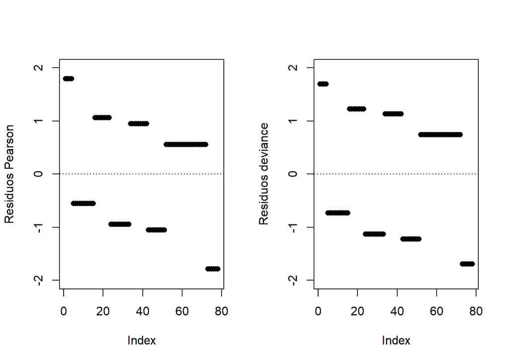

Abaixo, temos a curva ROC e valores para a sensibildiade, especificidade, VPP, VPN e acurárica do modelo 3. A sensibilidade foi bem baixa, ou seja, o modelo apresentou dificuldade em especificar corretamente os indivíduos com deonça. Já a especificidade, indicou boa especificação dos não doentes. Quanto ao VPP e VPN, ambos também foram bem baixos, indicando dificuldade de classificação dos desfechos pelo modelo. A acurácia final do model foi de $\approx 70\%$, o que pode ser considerada baixa, caso o modelo seja utilizado para classificação de novos indivíduos.

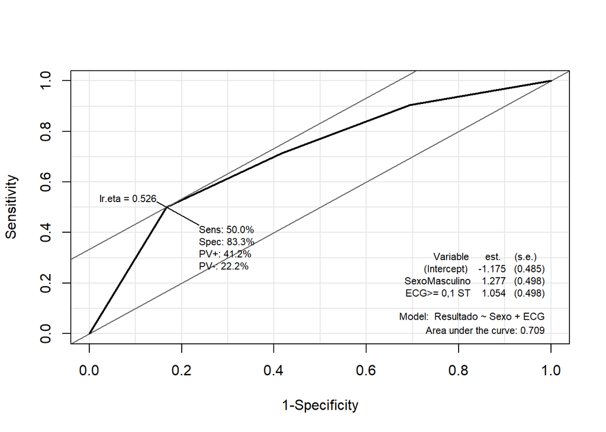

Por fim, vamos analisar as *odds ratio* ajustadas do modelo 3.

Obtemos uma *odds ratio* de 3,6 IC(1,35; 9,52) para os homens em relação as mulheres ajustada para ECG, indicando que os homens tem mais chance de desenvolverem doença coronária em relação as mulheres. Já a *odss ratio* para ECG $\leqslant 0,1$ em relação a ECG $<0,1$ foi de 2,87 IC(1,08;7,62); indicando que pacientes com ECG $\leqslant 0,1$ são mais propensos a desenvolver doença coronária.